# **Traffic Sign Recognition**

## Writeup Template

### You can use this file as a template for your writeup if you want to submit it as a markdown file, but feel free to use some other method and submit a pdf if you prefer.

**Build a Traffic Sign Recognition Project**

The goals / steps of this project are the following:

- Load the data set (see below for links to the project data set)
- Explore, summarize and visualize the data set
- Design, train and test a model architecture
- Use the model to make predictions on new images
- Analyze the softmax probabilities of the new images
- Summarize the results with a written report

### Data Set Summary & Exploration

#### 1. Provide a basic summary of the data set. In the code, the analysis should be done using python, numpy and/or pandas methods rather than hardcoding results manually.

I used the pandas library to calculate summary statistics of the traffic signs data set:

- The size of training set is: 34799
- The size of the validation set is: 4410
- The size of test set is: 12630
- The shape of a traffic sign image is: 32*32*3
- The number of unique classes/labels in the data set is: 43

#### 2. Include an exploratory visualization of the dataset.

Here is an exploratory visualization of the data set. It is a bar chart showing how different classes (traffic signs) are distributed among training, validation and testing data sets.

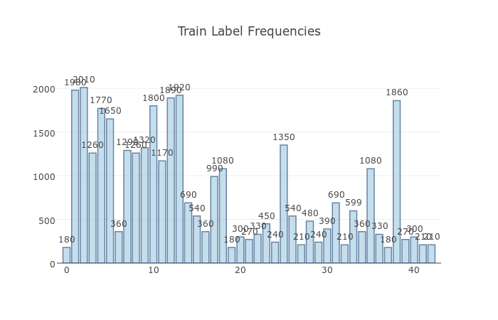

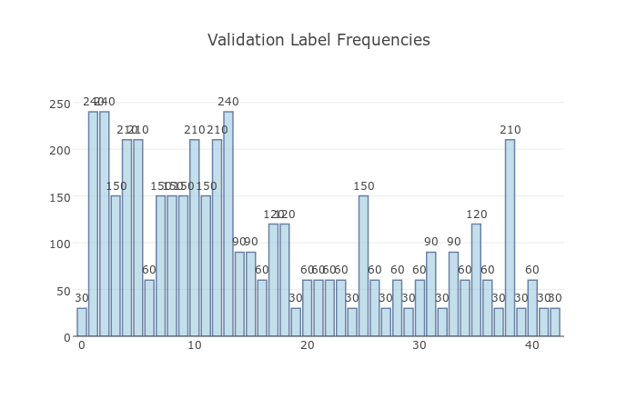

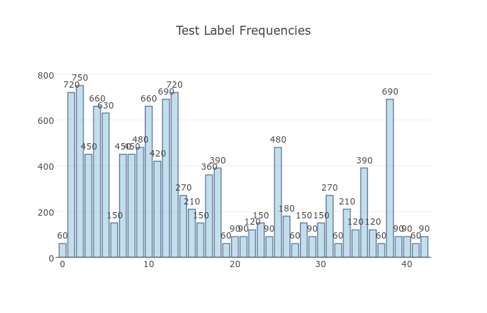

### Design and Test a Model Architecture

#### 1. Describe how you preprocessed the image data. What techniques were chosen and why did you choose these techniques? Consider including images showing the output of each preprocessing technique. Pre-processing refers to techniques such as converting to grayscale, normalization, etc. (OPTIONAL: As described in the “Stand Out Suggestions” part of the rubric, if you generated additional data for training, describe why you decided to generate additional data, how you generated the data, and provide example images of the additional data. Then describe the characteristics of the augmented training set like number of images in the set, number of images for each class, etc.)

As a first step, I decided to convert the images to brightness augmented images for Changing brightness to simulate day and night conditions. We will generate images with different brightness by first converting images to HSV, scaling up or down the V channel and converting back to the RGB channel.

Here is an example of a traffic sign image before and after brightness augmentation.

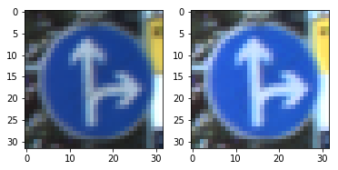

Brightness Augmentation

The reason to do this in the process of training our network, we’re going to multiply these features (pixel values) with weights and add biases in order to cause activations that we then backpropogate with the gradients to train the model.

We’d like in this process for each feature to have a similar range so that our gradients don’t go out of control (and that we only need one global learning rate multiplier).

Another way you can think about it is deep learning networks traditionally share many parameters - if you didn’t scale your inputs in a way that resulted in similarly-ranged feature values sharing wouldn’t happen very easily because to one part of the image weight w is a lot and to another it’s too small.

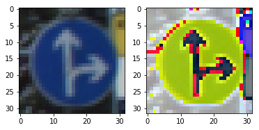

Normalized Images

As a last step, I converted all the images to grayscale images. By doing this we will have only single channel in image which will be computationally efficient while classifying them.

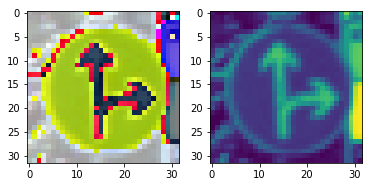

Grayscale Images

#### 2. Describe what your final model architecture looks like including model type, layers, layer sizes, connectivity, etc.) Consider including a diagram and/or table describing the final model.

My final model consisted of the following layers:

[output not shown]

#### 3. Describe how you trained your model. The discussion can include the type of optimizer, the batch size, number of epochs and any hyperparameters such as learning rate.

To train the model, I used an Adam Optimizer which will converge faster by using momentum. The batch size that I have chosen for this project is 128, number of epochs are 10 and the learning rate is 0.001. I have also used drop out and dropped 40% connections while training.

#### 4. Describe the approach taken for finding a solution and getting the validation set accuracy to be at least 0.93. Include in the discussion the results on the training, validation and test sets and where in the code these were calculated. Your approach may have been an iterative process, in which case, outline the steps you took to get to the final solution and why you chose those steps. Perhaps your solution involved an already well known implementation or architecture. In this case, discuss why you think the architecture is suitable for the current problem.

My final model results are:

- training set accuracy: 97.85%
- validation set accuracy: 93.4%
- test set accuracy: 91.45%

If a well known architecture was chosen:

- What architecture was chosen?

I have chosen the famous LeNet architecture proposed by Yann LeCun for traffic sign classification.

- Why did you believe it would be relevant to the traffic sign application?

LeNet is the most widely used architecture for image classification and it is a benchmark model to work on for image classification problems.

- How does the final model’s accuracy on the training, validation and test set provide evidence that the model is working well?

When we apply LeNet model directly on the traffic sign data we will get an accuracy of 89% on the validation data set. I performed certain preprocessing steps like - 1) Brightness Augmentation, 2) Image Normalization and 3) Gray Scale conversion.

### Test a Model on New Images

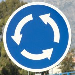

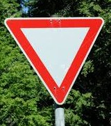

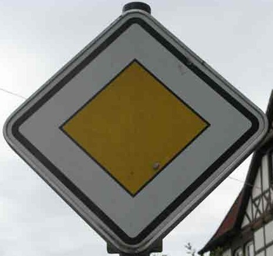

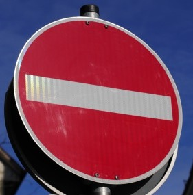

#### 2. Discuss the model’s predictions on these new traffic signs and compare the results to predicting on the test set. At a minimum, discuss what the predictions were, the accuracy on these new predictions, and compare the accuracy to the accuracy on the test set (OPTIONAL: Discuss the results in more detail as described in the “Stand Out Suggestions” part of the rubric).

Here are the results of the prediction:

| Image | Prediction |
| --- | --- |
| Roundabout mandatory | Roundabout mandatory |
| Speed limit (50km/h) | Speed limit (30km/h) |
| Yield | Yield |
| Priority road | Priority road |
| No entry | No entry |

The model was able to correctly guess 4 of the 5 traffic signs, which gives an accuracy of 80%.

#### 3. Describe how certain the model is when predicting on each of the five new images by looking at the softmax probabilities for each prediction. Provide the top 5 softmax probabilities for each image along with the sign type of each probability. (OPTIONAL: as described in the “Stand Out Suggestions” part of the rubric, visualizations can also be provided such as bar charts)

The code for making predictions on my final model is located in the 77th cell of the Jupyter notebook.

For the first image, the model is relatively sure that this is a Roundabout mandatory sign (probability of 0.8), and the image does contain a Roundabout mandatory sign. The top five soft max probabilities are:

| Probability | Prediction |
| --- | --- |
| .80 | Roundabout mandatory |
| .16 | Right-of-way at the next intersection |
| .003 | Priority road |
| $1.17e^{-3}$ | Speed limit (100km/h) |
| $5.45e^{-4}$ | Beware of ice/snow |

For the second image the top five soft max probablities and predicted tags:

| Probability | Prediction |
| --- | --- |
| .99 | Speed limit (30km/h) |
| $3.97e^{-3}$ | Speed limit (70km/h) |
| $1.57e^{-3}$ | Speed limit (20km/h) |
| $1.08e^{-3}$ | Speed limit (50km/h) |
| $1.59e^{-5}$ | Wild animals crossing |

For the third image the top five soft max probablities and predicted tags:

| Probability | Prediction |
| --- | --- |
| .99 | Yield |
| $1.008e^{-4}$ | Road work |
| $7.77e^{-8}$ | Turn right ahead |
| $4.56e^{-8}$ | No passing |
| $4.07e^{-9}$ | No vehicles |

For the fourth image the top five soft max probablities and predicted tags:

| Probability | Prediction |
| --- | --- |
| .96 | Priority road |
| .023 | Yield |
| $3.37e^{-3}$ | Roundabout mandatory |
| $1.76e^{-3}$ | No passing |
| $1.73e^{-3}$ | No entry |

For the fifth image the top five soft max probablities and predicted tags:

| Probability | Prediction |
| --- | --- |
| .99 | No entry |
| $1.80e^{-7}$ | Stop |
| $3.547e^{-11}$ | Priority road |
| $2.16e^{-11}$ | No vehicles |
| $1.03e^{-11}$ | End of all speed and passing limits |

### (Optional) Visualizing the Neural Network (See Step 4 of the Ipython notebook for more details)

#### 1. Discuss the visual output of your trained network’s feature maps. What characteristics did the neural network use to make classifications?